# Software

### QD PPMS - Keithley Electrometer interface program

Building off a project for a course (Hardware, Software, & Materials Chemistry), I developed a LabVIEW program to interface the McQueen Lab’s Quantum Design [Physical Properties Measurement System](https://www.qdusa.com/products/ppms.html) and Keithley electrometer. Together with a custom-built breakout box, this program allows users to collect resistance data beyond the typical range of a PPMS system while maintaining the usual control over temperature and magnetic field afforded by the PPMS. The program is also able to continuously collect and save data for each instrument independently. A user guide is in development.

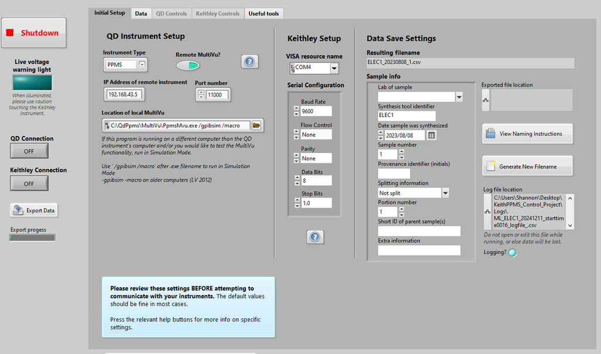

[figure not shown]

[figure not shown]

Although tailored for use in the McQueen Lab, in theory the program may be used with any compatible PPMS, MPMS, VersaLab, or DynaCool and any Keithley model 6517 or 6514. Software is available for download in VI form at https://github.com/sbernierjhu/ProjectJanus. Please contact sbernier@jhu.edu if you would like an executable version of the latest revision.

### SMBAnalysis

A small suite of analysis functions written in R is available here: https://github.com/sbernierjhu/SMBAnalysis. These tools have been used in publications within the McQueen lab covering Curie-Weiss analysis, computation of heat capacity from density of states, plotting data, and applying a cubicity metric to unit cell parameters. Documentation is included within the package so it is searchable within programs such as RStudio.

### PyCrystalField 5d transition metals

PyCrystalField is a Python package developed by [Allen Scheie](https://scholar.google.com/citations?user=Dq1Iq4IAAAAJ&hl=en) to calculate crystal field parameters of transition metal and rare earth ions directly from a .cif file, and to fit or calculate related experimental data. In collaboration with Dr. Scheie, I added functionality to incorporate additional transition metal ions (modified version [here](https://github.com/sbernierjhu/PyCrystalField)).

The new version does not include every possible transition metal or rare earth ion. To incorporate additional ions, three items are needed: 1) the S, L, and J (if applicable) values of each ion to be added, tabulated [here](https://physics.nist.gov/PhysRefData/Elements/per_noframes.html); 2) the radial integrals r^2, r^4, and r^6 (for rare earths) must be calculated (I used [this Fortran code](https://data.nist.gov/od/id/6CF509047B474AC9E05324570681DE731930)); and 3) for the transition metal ions, the spin orbit coupling constants must be found (preferably experimentally, but they may also be calculated in various ways). For rare earths, the shielding constants are required instead of spin orbit coupling constants. Note also that crystal field parameters can not be calculated for ions with S = 0.